# Syllabus

### Data and Computing Fundamentals [.](http://htmlpreview.github.com/?https://github.com/dtkaplan/DataAndComputingFundamentals/blob/master/Spring2013/syllabus2013.html)

### Spring 2013

#### Danny Kaplan and Libby Shoop, instructors

[Assignment Discussion Forum](https://moodle.macalester.edu/mod/forum/view.php?id=17817) on Moodle.

To update the DCF software: copy and paste these commands into your R console.

```r
require(devtools)
install_url("http://mosaic-web.org/go/Repository/DannyKaplan/DCF_0.13.tar.gz")
require(DCF)
```

### Resources

#### Software

**R and RStudio**. You will likely find it convenient to have an account on the server. If you don't already have one, you can [request one here](https://docs.google.com/a/macalester.edu/spreadsheet/viewform?formkey=dHJWYnlzdU10ZkFQRjRXcjhobWRORGc6MQ#gid=0).

**RPubs**: a site for distributing documents on the web. You'll hand in documents by cutting-and-pasting the URL into Moodle.

- HELP: A student volunteer is needed to make a video demonstrating this.

**R Markdown** Introduction Template

**R Syntax** Introduction Video

**R Chunks in R Markdown** Introduction

**Making Graphics**

- Scatter plots
- Bar plots

### Week 1

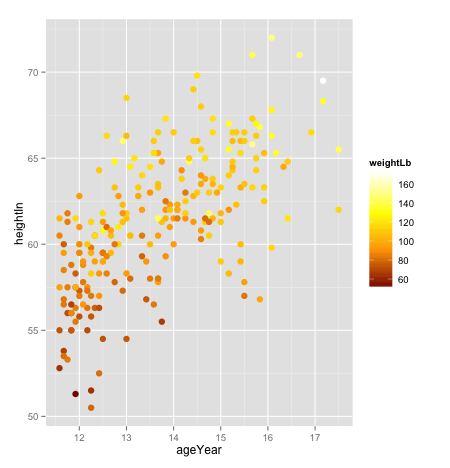

#### Topics:

- Welcome [Notes](http://htmlpreview.github.com/?https://github.com/dtkaplan/DataAndComputingFundamentals/blob/master/Notes/Day1/Day-1.html)
- Introduction to R and R/Markdown.
- The structure of data tables
- Scatter plots

#### In-Class

- R Syntax [Notes](http://htmlpreview.github.com/?https://github.com/dtkaplan/DataAndComputingFundamentals/blob/master/Notes/Day1/syntax-notes.html)
- Country-by-country size and population data

#### Out of Class

- Body shape and diabetes

#### Background

- [A cartoon about logarithms](http://xkcd.com/1162/)

#### To Hand in

| Topic | Instructions | Template | Hand in on Moodle |
| --- | --- | --- | --- |
| Exercises on syntax | [Description](http://htmlpreview.github.com/?https://github.com/dtkaplan/DataAndComputingFundamentals/blob/master/Notes/Day1/syntax-exercises.html) | [Rmd Template](https://raw.github.com/dtkaplan/DataAndComputingFundamentals/master/Notes/Day1/syntax-exercises.Rmd) | [Moodle link](https://moodle.macalester.edu/mod/assign/view.php?id=17814) |
| Country data on the web | [Description](http://htmlpreview.github.com/?https://github.com/dtkaplan/DataAndComputingFundamentals/blob/master/Notes/Day1/Data-on-the-web.html) |  | [Moodle link](https://moodle.macalester.edu/mod/assign/view.php?id=18513) |
| Country-by-country data | [Description](http://htmlpreview.github.com/?https://github.com/dtkaplan/DataAndComputingFundamentals/blob/master/Notes/Day1/in-class-activity.html) | [Rmd Template](https://raw.github.com/dtkaplan/DataAndComputingFundamentals/master/Templates/UNFAO-week1.Rmd) | [Moodle link](https://moodle.macalester.edu/mod/assign/view.php?id=17816) |
| Body shape data | [Description](http://htmlpreview.github.com/?https://github.com/dtkaplan/DataAndComputingFundamentals/blob/master/Notes/Day1/body-shape.html) | [Rmd Template](https://raw.github.com/dtkaplan/DataAndComputingFundamentals/master/Notes/Day1/body-shape-template.Rmd) | [Moodle link](https://moodle.macalester.edu/mod/assign/view.php?id=17815) |

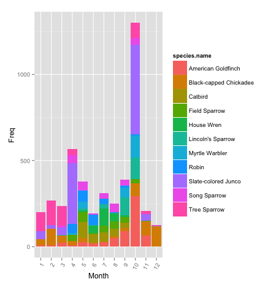

### Week 2

#### Topics

- [Creating Small Data with a Spreadsheet](http://htmlpreview.github.com/?https://github.com/dtkaplan/DataAndComputingFundamentals/blob/master/Notes/Day2/CreatingSmallTables.html)
- [Subsets](http://htmlpreview.github.com/?https://github.com/dtkaplan/DataAndComputingFundamentals/blob/master/Notes/Day2/subsets.html)
- [Groupwise analysis](http://htmlpreview.github.com/?https://github.com/dtkaplan/DataAndComputingFundamentals/blob/master/Notes/Day2/GroupBy.html)
- [Bar Plots](http://htmlpreview.github.com/?https://github.com/dtkaplan/DataAndComputingFundamentals/blob/master/Notes/Day2/CreatingBarPlots.html)

#### In Class

- Debriefing: Scatter Plots and Data Organization
- Introduction: Subsets, Grouping, Bar Plots
- Pre-populated [math enrollment spreadsheet](https://docs.google.com/spreadsheet/ccc?key=0AkXIvAg85dhhdHdONnZ6aWwtRDZtc2ZyN2QxeEdJMFE&usp=sharing#gid=0) to **copy**, complete, publish, and read in to R.
- In-Class Data: Birds at Ordway
- After-Class Data: Voters

#### To Hand in

| Topic | Instructions | Template | Hand in on Moodle |
| --- | --- | --- | --- |
| Exercises | [Description](http://htmlpreview.github.com/?https://github.com/dtkaplan/DataAndComputingFundamentals/blob/master/Notes/Day2/Exercises-2.html) | [Rmd Template](https://raw.github.com/dtkaplan/DataAndComputingFundamentals/master/Notes/Day2/Exercises-2-template.Rmd) | [Moodle link](https://moodle.macalester.edu/mod/assign/view.php?id=18806) |
| Bird data | [Description](http://htmlpreview.github.com/?https://github.com/dtkaplan/DataAndComputingFundamentals/blob/master/Notes/Day2/BirdCounts.html) | [Rmd Template](https://raw.github.com/dtkaplan/DataAndComputingFundamentals/master/Notes/Day2/BirdCounts.Rmd) | [Moodle link](https://moodle.macalester.edu/mod/assign/view.php?id=18807) |
| Voter data | [Description](http://htmlpreview.github.com/?https://github.com/dtkaplan/DataAndComputingFundamentals/blob/master/Notes/Day2/voters.html) | [Rmd Template](https://raw.github.com/dtkaplan/DataAndComputingFundamentals/master/Notes/Day2/voters.Rmd) | [Moodle link](https://moodle.macalester.edu/mod/assign/view.php?id=18808) |

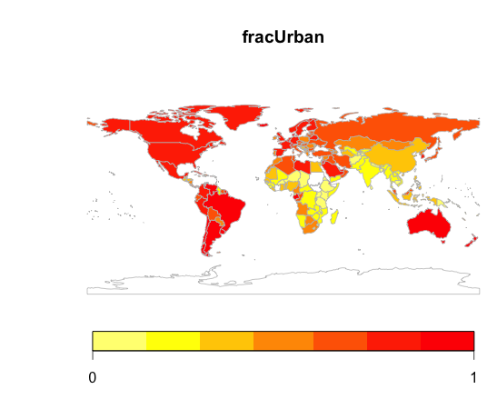

### Week 3

### Topics

- [Data across many files: Gapminder](http://htmlpreview.github.com/?https://github.com/dtkaplan/DataAndComputingFundamentals/blob/master/Notes/Day3/GapminderFiles.html)
- [Wide and Narrow Data](http://htmlpreview.github.com/?https://github.com/dtkaplan/DataAndComputingFundamentals/blob/master/Notes/Day3/WideVsLong.html)
- [Continuous to Categorical](http://htmlpreview.github.com/?https://github.com/dtkaplan/DataAndComputingFundamentals/blob/master/Notes/Day3/Continuous2Categorical.html)
- [Drawing Maps](http://htmlpreview.github.com/?https://github.com/dtkaplan/DataAndComputingFundamentals/blob/master/Notes/Day3/Maps.html)

### In-Class

- Gapminder files
- Operations on Narrow Data
- Continuous to Categorical
- Joining two similar data files
- Maps

#### To Hand in

| Topic | Instructions | Template | Hand in on Moodle |
| --- | --- | --- | --- |
| Exercises | [Description](http://htmlpreview.github.com/?https://github.com/dtkaplan/DataAndComputingFundamentals/blob/master/Notes/Day3/Exercises-3.html) | [Rmd Template](https://raw.github.com/dtkaplan/DataAndComputingFundamentals/master/Notes/Day3/Exercises-3.Rmd) | [Moodle link](https://moodle.macalester.edu/mod/assign/view.php?id=19987) |
| Exploring Gapminder | [Description](http://htmlpreview.github.com/?https://github.com/dtkaplan/DataAndComputingFundamentals/blob/master/Notes/Day3/Exercises-Maps.html) | [Rmd Template](https://raw.github.com/dtkaplan/DataAndComputingFundamentals/master/Notes/Day3/Exercises-Maps.Rmd) | [Moodle link](https://moodle.macalester.edu/mod/assign/view.php?id=19989) |

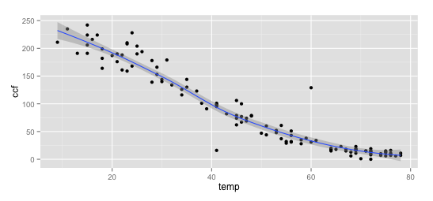

### Week 4

#### Topics

- [Model Functions](http://htmlpreview.github.com/?https://github.com/dtkaplan/DataAndComputingFundamentals/blob/master/Notes/Day4/ModelFunctions.html)
- [Uses for Join](http://htmlpreview.github.com/?https://github.com/dtkaplan/DataAndComputingFundamentals/blob/master/Notes/Day4/Join-notes.html)
- [Data Cleaning](http://htmlpreview.github.com/?https://github.com/dtkaplan/DataAndComputingFundamentals/blob/master/Notes/Day4/CleaningTheBirds.html)

#### In-Class

- Functions, fits, and confidence intervals
- Uses for Join
- Crowd-sourcing data cleaning: Bird Species. The [species name spreadsheet for editing](https://docs.google.com/spreadsheet/ccc?key=0Av2C2RiwUxpVdFlPWUp6NERSQzhld3o4QklQd1p6d2c&usp=sharing). The link for [reading in the editing file to R](https://docs.google.com/spreadsheet/pub?key=0Av2C2RiwUxpVdFlPWUp6NERSQzhld3o4QklQd1p6d2c&single=true&gid=0&output=csv).

#### To Hand in

| Topic | Instructions | Template | Hand in on Moodle |
| --- | --- | --- | --- |
| Exercises | [Description](http://htmlpreview.github.com/?https://github.com/dtkaplan/DataAndComputingFundamentals/blob/master/Notes/Day4/Exercises-4.html) | [Rmd Template](https://raw.github.com/dtkaplan/DataAndComputingFundamentals/master/Notes/Day4/Exercises-4.Rmd) | [Moodle link](https://moodle.macalester.edu/mod/assign/view.php?id=21837) |
| Arsenic in Wells | to be posted |  |  |

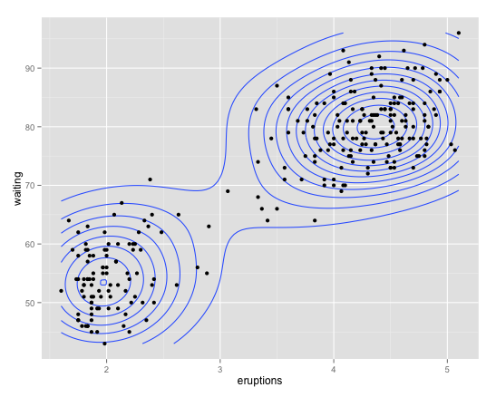

### Week 5

#### Topics

Overview: [From Two to Several](http://htmlpreview.github.com/?https://github.com/dtkaplan/DataAndComputingFundamentals/blob/master/Notes/Day5/SeveralVariables.html)

- [Graphics: Parallel Coordinates](http://htmlpreview.github.com/?https://github.com/dtkaplan/DataAndComputingFundamentals/blob/master/Notes/Day5/ParallelCoordinates.html)
- [Programming for Repeating](http://htmlpreview.github.com/?https://github.com/dtkaplan/DataAndComputingFundamentals/blob/master/Notes/Day5/BasicProgramming.html)
- [Clustering: Position =>> Groups](http://htmlpreview.github.com/?https://github.com/dtkaplan/DataAndComputingFundamentals/blob/master/Notes/Day5/Clustering.html)

#### To Hand in

| Topic | Instructions | Template | Hand in on Moodle |
| --- | --- | --- | --- |
| Exercises | [Description](http://htmlpreview.github.com/?https://github.com/dtkaplan/DataAndComputingFundamentals/blob/master/Notes/Day5/Exercises-5.html) | [Rmd Template](https://raw.github.com/dtkaplan/DataAndComputingFundamentals/master/Notes/Day5/Exercises-5.Rmd) | [Moodle link](https://moodle.macalester.edu/mod/assign/view.php?id=21838) |
| Book Reviews | [Link to Shared Document](https://docs.google.com/document/d/1NWWE-pW5Lo2aJBuAjOs8w4mq-MQpSL1mXxj1HQ8WXmc/edit?usp=sharing) |  |  |
| … |  |  |  |
| … |  |  |  |

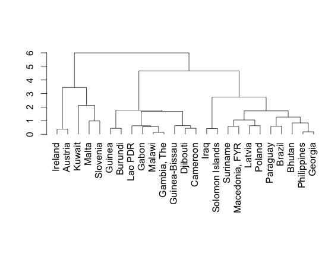

### Week 6

#### In Class

- A review activity: Consumer Financial Protection Bureau complaints. [Activity Description](http://htmlpreview.github.com/?https://github.com/dtkaplan/DataAndComputingFundamentals/blob/master/Notes/Day6/reviewActivity.html)
- Hierarchical Clustering
- Supervised Partitioning
- Dimension Reduction (to be added)

#### Topics

- Dendrograms and Hierarchical Clustering [Notes](http://htmlpreview.github.com/?https://github.com/dtkaplan/DataAndComputingFundamentals/blob/master/Notes/Day6/dendrograms.html)
- Supervised Partitioning [Notes](http://htmlpreview.github.com/?https://github.com/dtkaplan/DataAndComputingFundamentals/blob/master/Notes/Day6/Partitioning.html)
- After-class notes: Toward a strategy of table design [draft](http://htmlpreview.github.com/?https://github.com/dtkaplan/DataAndComputingFundamentals/blob/master/Notes/Day6/StrategizingCFPB.html)

#### To Hand in

| Topic | Instructions | Hand in on Moodle |
| --- | --- | --- |
| Exercises | [Description](http://htmlpreview.github.com/?https://github.com/dtkaplan/DataAndComputingFundamentals/blob/master/Notes/Day6/Exercises-6.html) | [Moodle link](https://moodle.macalester.edu/mod/assign/view.php?id=21839) |
| Book Reviews | [Link to Shared Document](https://docs.google.com/document/d/1NWWE-pW5Lo2aJBuAjOs8w4mq-MQpSL1mXxj1HQ8WXmc/edit?usp=sharing) |  |

### Week 7

#### Topics

- Mining information from words: [a radio report](http://www.npr.org/blogs/health/2013/04/01/175584297/mining-books-to-map-emotions-through-a-century) on mapping emotions across the years.
- [GoogleNgrams](http://htmlpreview.github.com/?https://github.com/dtkaplan/DataAndComputingFundamentals/blob/master/Notes/Day7/GoogleNgrams.html)
- [Regular expressions](http://htmlpreview.github.com/?https://github.com/dtkaplan/DataAndComputingFundamentals/blob/master/Notes/Day7/RegEx.html)

#### To Hand in

| Topic | Instructions |
| --- | --- |
| Book Reviews | [Link to Shared Document](https://docs.google.com/document/d/1NWWE-pW5Lo2aJBuAjOs8w4mq-MQpSL1mXxj1HQ8WXmc/edit?usp=sharing) |
| **Required Survey** | [Link to Google Form](https://docs.google.com/a/macalester.edu/spreadsheet/viewform?fromEmail=true&formkey=dEN4WkstRGJWRy13MlI0N0RBNDlZWHc6MQ) |

You **must** do the survey to receive credit for the course. Thanks.

#### Notes for future development

[Revision ideas](http://htmlpreview.github.com/?https://github.com/dtkaplan/DataAndComputingFundamentals/blob/master/Notes/RevisionIdeas.html)